# Verzani Problem Set

## Problem 9.3

Do a t-test on the same data. Is it correct?

```r
> t.test(x, conf.level = 0.95)

    One Sample t-test

data:  x
t = 7.9346, df = 14, p-value = 1.507e-06
alternative hypothesis: true mean is not equal to 0
95 percent confidence interval:
  8.476948 14.757414
sample estimates:
mean of x
 11.61718
```

```r
> tTest <- function(data, conf.level = 0.95) {
+   alpha <- 1 - conf.level
+   zstar <- qt(1 - alpha / 2, length(data)-1)
+   SE <- sd(x) / sqrt(length(data))
+   mean(data) + c(-zstar*SE, zstar*SE)
+ }
> tTest(x, conf.level = 0.95)
[1]  8.476948 14.757414
```

Do it $100$ times. Compute in what percentage the 95% t-test confidence interval contains the expectation?

```r
> num <- 0
> for (i in 1:100) {
+   x <- rnorm(15, mean = 10, sd = 5)
+   ci <- tTest(x, conf.level = 0.95)
+   if (ci[1] <= 10 & 10 <= ci[2]) {
+     num <- num + 1
+   }
+ }
> num
[1] 96
> num / 100
[1] 0.96
```

## Problem 9.4

Find an $80\%$ and $95\%$ confidence interval for the median for the `exec.pay` dataset.

```r
> median(exec.pay)
[1] 27
```

$80\%$ confidence interval for the median

```r
> wilcox.test(exec.pay, conf.level = 0.80, conf.int=TRUE)

    Wilcoxon signed rank test with continuity correction

data:  exec.pay
V = 19306, p-value < 2.2e-16
alternative hypothesis: true location is not equal to 0
80 percent confidence interval:
 27.00005 31.49996
sample estimates:
(pseudo)median
      29.00002
```

$95\%$ confidence interval for the median

```r
> ci95 <- wilcox.test(exec.pay, conf.level = 0.95, conf.int=TRUE); ci95

    Wilcoxon signed rank test with continuity correction

data:  exec.pay
V = 19306, p-value < 2.2e-16
alternative hypothesis: true location is not equal to 0
95 percent confidence interval:
 25.99998 32.99994
sample estimates:
(pseudo)median
      29.00002
```

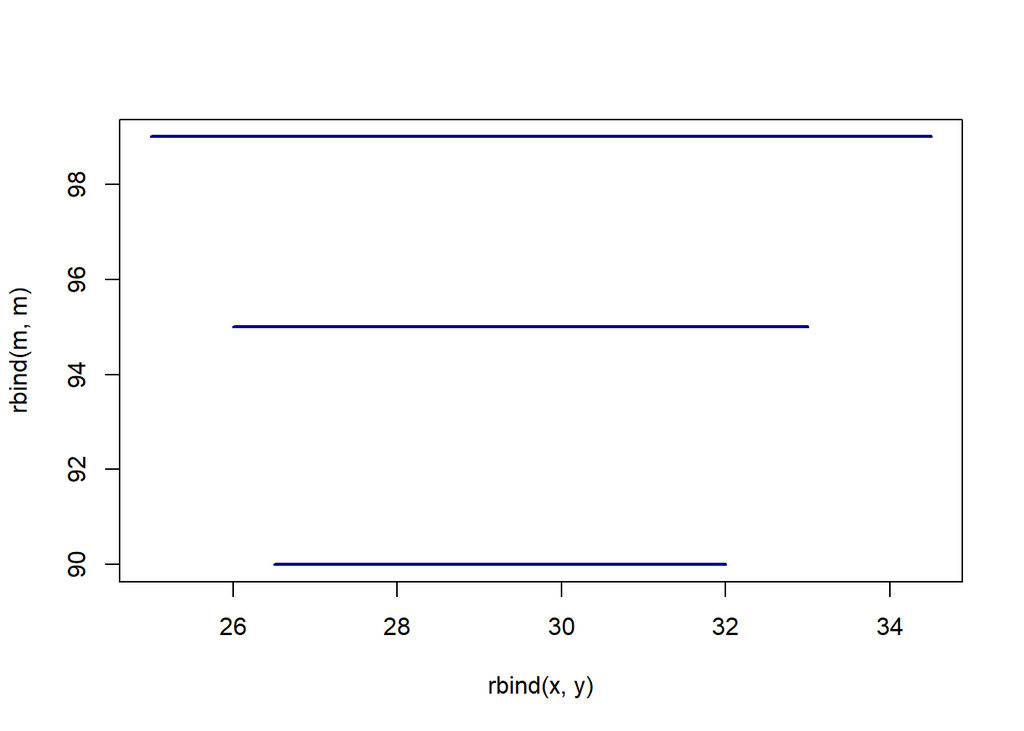

```r
> ci90 <- wilcox.test(exec.pay, conf.level = 0.90, conf.int=TRUE)
> ci99 <- wilcox.test(exec.pay, conf.level = 0.99, conf.int=TRUE)
> m <- c(90, 95, 99)
> x <- c(ci90$conf.int[1], ci95$conf.int[1], ci99$conf.int[1])
> y <- c(ci90$conf.int[2], ci95$conf.int[2], ci99$conf.int[2])
> matplot(rbind(x, y), rbind(m, m),
+         type="l", lty=1, lwd = 2,
+         col = "darkblue")
```

## Problem 9.5

The data set `rat` records survival times for rats exposed to radiation. Do a t-test for the mean if the data suggests it is appropriate. If not, say why not.

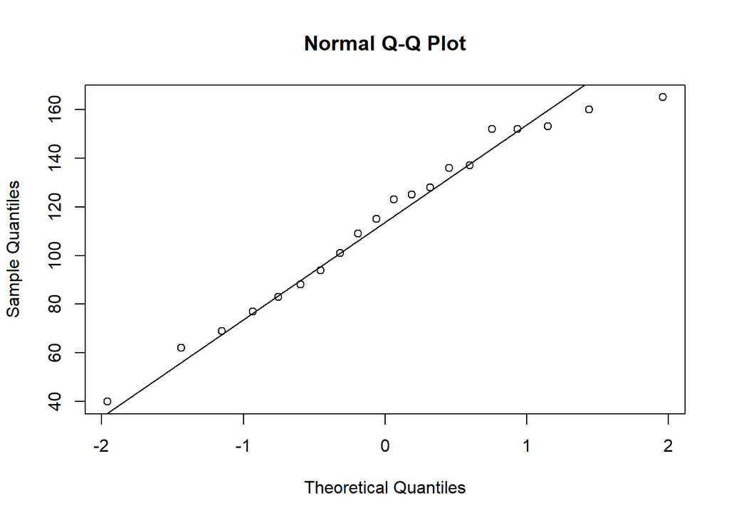

```r
> qqnorm(rat)
> qqline(rat)
```

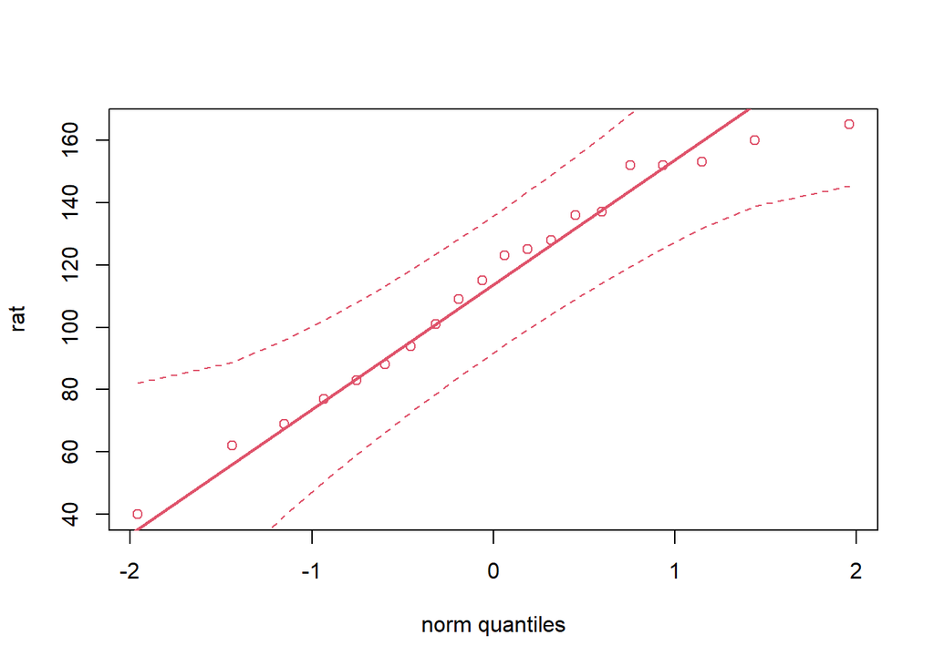

```r
> library(StatDA)
Warning: package 'StatDA' was built under R version 4.0.3
Loading required package: sgeostat
Warning: package 'sgeostat' was built under R version 4.0.3
Registered S3 method overwritten by 'geoR':
  method         from
  plot.variogram sgeostat
> qqplot.das(rat, "norm")
```

```r
> shapiro.test(rat)

    Shapiro-Wilk normality test

data:  rat
W = 0.96134, p-value = 0.571
```

As we see from the graphics and from the $p-value = 0.571 > 0.05 = \alpha$ we can assume that the data is normally distributed.

The data sample is small.

```r
> length(rat)
[1] 20
```

It has $20$ observations, but we see that we can assume that they are normally distributed. $\sigma$ is unknown. Therefore, we use the `t.test`

```r
> t.test(rat)

    One Sample t-test

data:  rat
t = 14.176, df = 19, p-value = 1.48e-11
alternative hypothesis: true mean is not equal to 0
95 percent confidence interval:
  96.69997 130.20003
sample estimates:
mean of x
   113.45
```

## Problem 9.6

Repeat the previous for the data set `puerto` containing weekly incomes of Puerto Ricans in Miami.

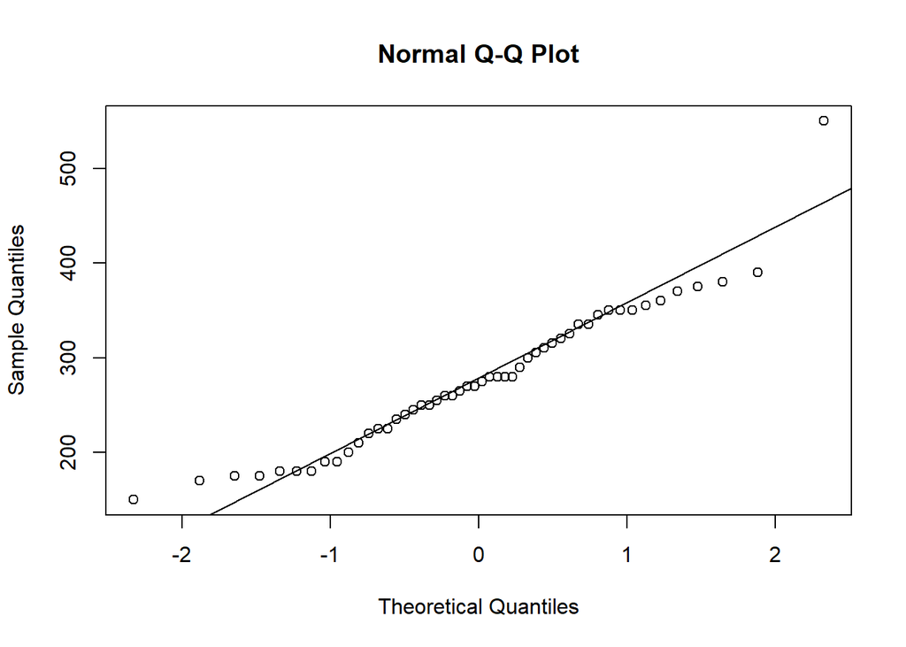

```r
> qqnorm(puerto)
> qqline(puerto)
```

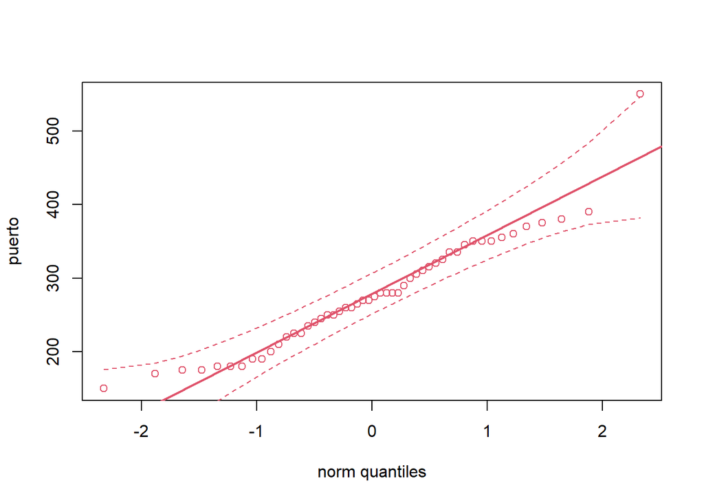

```r
> qqplot.das(puerto, "norm")
```

```r
> shapiro.test(puerto)

    Shapiro-Wilk normality test

data:  puerto
W = 0.94538, p-value = 0.02212
```

As we see from the graphics and from the $p-value = 0.02 < 0.05 = \alpha$ we can’t assume that the data is normally distributed.

The data sample is not very small.

```r
> length(puerto)
[1] 50
```

It has $50$ observations and $\sigma$ is unknown.

If the $\sigma < \infty$ we can use the CLT and obtain

```r
> t.test(puerto)

    One Sample t-test

data:  puerto
t = 25.847, df = 49, p-value < 2.2e-16
alternative hypothesis: true mean is not equal to 0
95 percent confidence interval:
 255.9244 299.0756
sample estimates:
mean of x
    277.5
```

Can we also make a $95\%$ confidence interval for the standard deviation? If yes, make a two-sided confidence interval. If not, say why not.

Due to the previous considerations and as $\mu$ is unknown.

```r
> n <- length(puerto)
> s <- sd(puerto, na.rm = TRUE)
> alpha <- 0.05
> xstar1 <- qchisq(1 - alpha/2, n - 1)
> xstar2 <- qchisq(alpha/2, n - 1)
> leftend <- sqrt(s^2 * (n-1) / xstar1)
> rightend <- sqrt(s^2 * (n-1) / xstar2)
> c(leftend, rightend)
[1] 63.41676 94.60377
```

## Problem 9.7

Find a $90\%$ confidence interval for the center for the data set `malpract`, containing the size of malpractice awards. Is z-test and t-test appropriate for this data? If not comment why this distribution doesn’t lend itself to the z-test or t-test.

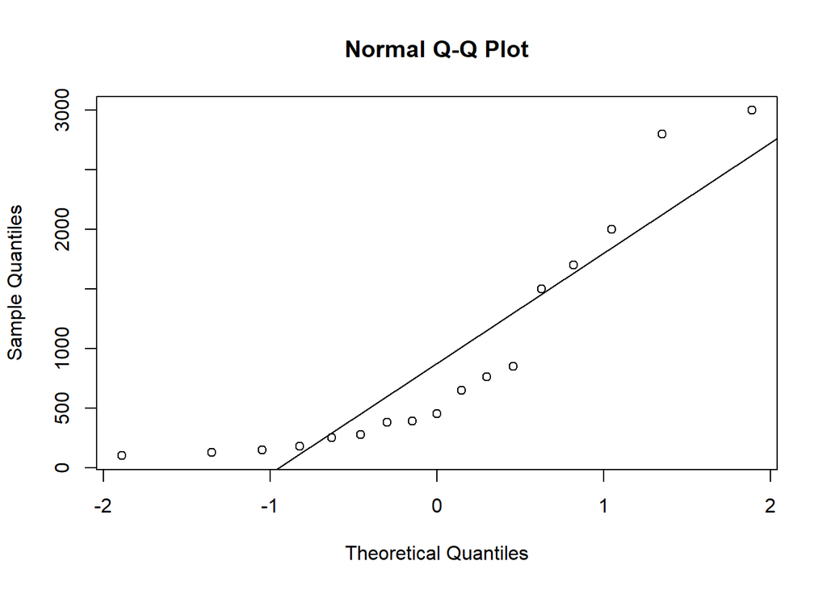

```r
> qqnorm(malpract)
> qqline(malpract)
```

```r
> shapiro.test(malpract)

    Shapiro-Wilk normality test

data:  malpract
W = 0.80547, p-value = 0.002414
```

As we see from the $p-value = 0.002 < 0.05 = \alpha$ we can’t assume that the data is normally distributed.

The data sample is small.

```r
> length(malpract)
[1] 17
```

It has $17$ observations and we can’t assume that the data is normally distributed. Therefore, we can perform Wilcoxon confidence interval for the median.

```r
> wilcox.test(malpract, conf.level = 0.90, conf.int = TRUE)

    Wilcoxon signed rank exact test

data:  malpract
V = 153, p-value = 1.526e-05
alternative hypothesis: true location is not equal to 0
90 percent confidence interval:
  385 1325
sample estimates:
(pseudo)median
           800
```